# Introduction to boundary line analysis

This Vignette describe the theory of boundary line analysis and the process fitting the boundary line to a data set.

# Background

When a biological response, *`y`*, is observed as function of a single factor of interest, *`x`*, in an uncontrolled environment i.e. when the influence of other factors is not controlled, a scatter of observations is observed due to the many sources of variation. If, for example, *`x`* along with other factors contributes in some additive way to variation of *`y`* then then a bivariate normal distribution may be expected. However, more complex effects are possible. For example, if the data set is large enough to contain a wide range of combinations of conditions, and x and other factors influence y in accordance with some non-linear process as characterized by the law of the minimum, or the law of the optimum (see Miti *et al*, 2024a), then the data points that are observed in most favourable conditions for the response *`y`* will fall at the upper edges of the data cloud, which would be the maximum possible response of *`y`* given some value of *`x`*. The data points that fall below the maximum response are as a result of the limiting effect of other factors that are not controlled for. Webb (1972) suggested a methodology that can be used to describe the relationship of data points at the upper edges of such data sets which is the most likely relationship of *`y`* and *`x`* when all other factors are not limiting. He referred to this relationship as the boundary line.

The initial boundary line method by Webb (1972) involved the selection of data points at the upper edges of the data cloud visually. The boundary line model was then fitted to the selected data points to describe the relationship. Currently, many other procedures of fitting the boundary line model to the dataset have been developed to improve the procedure some of which are statistical and some heuristic. These include binning, BOLIDES, quantile regression, makowski quantile regression and the censored bivariate normal methods. Similarly, data exploratory methods have been developed that provide evidence of boundary existence in a dataset which therefore, justifies the use of boundary line analysis on a data set (Milne *et al*. 2006). Colleagues of Webb (1972), who provided the initial data on which boundary line analysis was first applied, were not convinced that the data realized a boundary, hence the need for testing of data sets for presence of boundary. If a boundary exists in data set, it is expected that the distribution of points at the upper edges of data cloud would be clustered and not randomly distributed because response can not go beyond the observed boundary. Evidence for such a distribution provides grounds for proceeding to a boundary line analysis, and Miti *et al*. (2024b) describe the method which this package provides to evaluate this evidence. It should be noted that more powerful testing against an alternative bivariate normal distribution can be done after fitting a boundary line model with the `cbvn()` function.

The `BLA` package provides a group of functions to carryout boundary line analysis on a data set in `R` software. It includes functions to explore data, test evidence of boundary in a data set, fit the boundary line and do post-hoc analysis after fitting a boundary line.

# Boundary line analysis using BLA package

## Load the BLA package

With the `BLA` package installed, the first step is to load it to your R session using the `library()` command.

```r
library(BLA)
```

```r
library(aplpack)
```

The package `aplpack` has also been loaded for use in the outlier detection function `bagplot()`.

## Data

The `BLA` package contains a data set called soil which consisting of soil pH, phosphorus and wheat yield measurements from farms in the UK. We will use this data set to illustrate the functions in the `BLA` package. To view the first six lines of the data, run the code below:

```r
head(soil)
```

```
#>      yield   pH  P
#> 1  9.55787 6.66 10
#> 2  8.88999 6.92  9
#> 3  8.38731 6.83 10
#> 4  9.19583 6.34  9
#> 5  9.83057 6.74  9
#> 6 11.88140 6.54 12
```

## Exploratory analysis

### Normality test

To assess the distribution of the data, the `summastat()` function provides different summary statistics and the graphical representation of the variable distribution. Let us set the variables P and wheat yield in the data set to *`x`* and *`y`* respectively before applying the `summastat()` functions

```r
x<-soil$P
y<-soil$yield
```

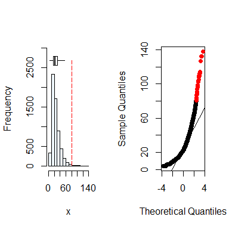

```
#>         Mean Median Quartile.1 Quartile.3 Variance       SD Skewness
#> [1,] 25.9647     22         16         32 207.0066 14.38772 1.840844
#>      Octile skewness Kurtosis No. outliers
#> [1,]       0.3571429 5.765138           43

summastat(y)
```

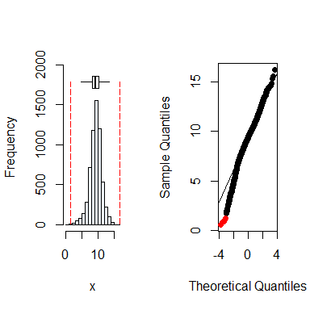

```
#>          Mean  Median Quartile.1 Quartile.3 Variance       SD   Skewness
#> [1,] 9.254813 9.36468   8.203703   10.39477 3.456026 1.859039 -0.4819805
#>      Octile skewness Kurtosis No. outliers
#> [1,]     -0.05793291 1.292635            7
```

```r
summastat(x)
```

From the results, wheat yield (*`y`*) variables can be considered to be normally distributed while the soil P (*`x`*) is skewed. For a variable to be assumed to be from a normal distribution, the indices skewness should be between -1 to 1 and Octile skewness between -0.2 to 0.2. A graphical representation of the distribution is given as well.

The soil P can be log transformed and check the summary statistics and plot

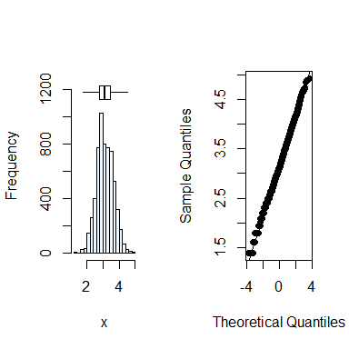

```
#>          Mean   Median Quartile.1 Quartile.3  Variance        SD  Skewness
#> [1,] 3.126361 3.091042   2.772589   3.465736 0.2556936 0.5056615 0.1297406
#>      Octile skewness    Kurtosis No. outliers
#> [1,]      0.08395839 -0.05372586            0

x<-log(x) # transforms soil P to log
```

```r
summastat(log(x))
```

From the results, variable log of soil P can be assumed to be from a normal distribution.

### Outlier detection and removal

1. **depth median** which represent the center of the data cloud. This is equivalent to the median in a univariate box-plot
2. **Bag** which contains 50% of all the data points. This is equivalent to the inter-quartile range in a univariate box-plot.
3. **Loop** which contains all points that are outside the bag but are not outliers
4. **Outliers** which are values outside the loop

```r
vals_ur<-matrix(NA,length(x),2) #Create a matrix with x and y as required by the bag plot function
vals_ur[,1]<-x
vals_ur[,2]<-y

bag<-bagplot(vals_ur, ylim=c(0,20), show.whiskers =F,create.plot = TRUE) # run the bagplot function
legend("topright", c("bag","loop","outliers", "d.median"),
        pch = c(15,15,16,8),col=c("blue","lightblue","red","red"),
       cex=0.7)

vals<-rbind(bag$pxy.bag,bag$pxy.outer) # to remove outliers, select points in the bag and loop only
```

[output not shown]

The variables *`x`* and *`y`* and now be extracted from the results of the bag plot with outliers removed

```r
x<-vals[,1]
y<-vals[,2]
```

### Test for presence of boundary in dataset

The function `exp_boundary()` can be used to evaluate evidence that observations are clustered near an upper boundary in a data set, testing this against an unbounded bivariate normal distribution as a null hypothesis. The standard deviation (*sd*) of the the Euclidean distance of the boundary points to the centre of the data set is used to measure the density of the points at the upper edges of the data. The smaller the *sd* value, the denser the distribution. This function uses the convex hull to select the points at the upper boundary. The default is selecting the first 10 consecutive convex hulls (`shells=10`). The convex hulls are then splits into two sections, the right and left sections, and evidence of boundary existence in both sections is checked by determining the probability of having the observed density of points at the upper edges of the data under the bivariate normal null hypothesis. More detail is provided by Miti *et al*. 2024b. We reject the null hypothesis if p< 0.05.

```r
bound_test<-expl_boundary(x,y,shells = 10, simulations = 100,
                          pch=16, col="grey") #
```

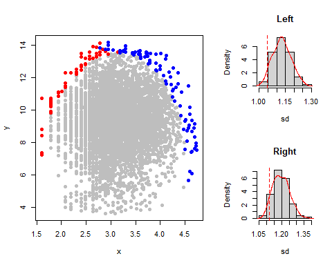

```r
bound_test
```

```
#>     Index Section    value
#> 1      sd    Left 1.045711
#> 2      sd   Right 1.115379
#> 3 Mean sd    Left 1.130030
#> 4 Mean sd   Right 1.196605
#> 5 p_value    Left 0.030000
#> 6 p_value   Right 0.050000
```

## Fitting boundary line using different methods

### Bolides algorithm

This method fit the boundary line following the boundary line determination technique proposed by Schnug *et al.* (1995). To fit the boundary line using the BOLIDES algorithm , the `bolides()` function can be used. To check the required arguments for the function, the help page can be launched.

```r
?bolides
```

The arguments *`x`* and *`y`* are the independent and dependent variable respectively and `start` is a vector of starting values . The `model` argument is used to specify the model of the boundary line e.g. “blm” for the linear model. The `xmax` is an argument that describes the maximum value of the independent variable beyond which the relation of *`x`* and *`y`* is no longer theoretically feasible. Other arguments relate to the plot parameters as in the `plot()` function.

All boundary fitting methods require initial starting values for the parameters of a proposed model. The initial starting values are optimized to find the parameters of the proposed model as in the `optim()` function in base `R`.

To get the start starting values, the `bolides()` function is run with the argument `model="explore"`. This allows us to view the selected boundary points using the boundary line determination technique.

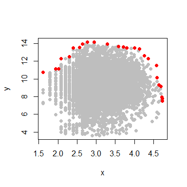

```
#>        x               y
#>  Min.   :1.609   Min.   : 7.513
#>  1st Qu.:2.583   1st Qu.:10.817
#>  Median :3.649   Median :12.566
#>  Mean   :3.464   Mean   :11.965
#>  3rd Qu.:4.520   3rd Qu.:13.575
#>  Max.   :4.736   Max.   :14.159
```

```r
bolides(x,y,model = "explore", pch=16, col="grey")
```

From the plot, it can be seen that a “trapezium” model will be more appropriate for this data set. The function `startValues()` can be used to determine initial start values. For more information on `startValues()` function see `?startValues()`.

```r
?startValues()
```

With a scatter plot of *`y`* against *`x`* active in the plot window in `R`, run the function `startValues("trapezium")`, then use the mouse to click on the plot at five boundary points that follow the trapezium model in order of increasing *`x`* values.

```r
startValues("trapezium") # then select the five points at the edge of the dataset that make up the trapezium model in order of increasing x values.
```

The proposed start values will be produced. Note that this can be done for other models as well. Once all the arguments are set, the function can be run

```r
start<-c(4,3,14,104,-22) # start values is a vector of five consists of intercept, slope, plateau yield, intercept2 and slope2.

model1<-bolides(x,y, start = start,model = "trapezium",
                xlab=expression("Phosphorus/ln(mg L"^-1*")"),
                ylab=expression("Yield/ t ha"^-1), pch=16,
                col="grey", bp_col="grey")
```

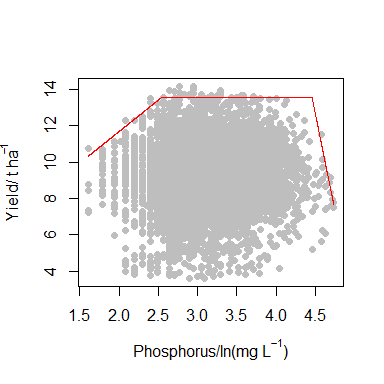

```r
model1
```

```
#> $Model
#> [1] "trapezium"
#>
#> $Equation
#> [1] y = min(β₁ + β₂x, β₀, β₃ + β₄x)
#>
#> $Parameters
#>      Estimate
#> β₁   4.765511
#> β₂   3.456652
#> β₀  13.573119
#> β₃ 108.346207
#> β₄ -21.263562
#>
#> $RMS
#> [1] 0.2174186
```

The results show that the optimized parameters and plot of the fitted model. There is no uncertainty in the parameters because this is a heuristic method.

These parameters can then be used to determine boundary line response for any given value of *`x`*. Say you want to predict the maximum possible yield response at soil P values of 4.5, 7.4, 12.2, 20.1 and 54.5 mg/kg. Remember that our model was fitted on values of log soil P and therefore, these values must first be log transformed before the prediction is made. We can use the function `predictBL()` for this purpose. For more information on this function, see `?predictBL()` .

```r
P<-c(4.5, 7.4, 12.2, 20.1, 54.5)
P_log<-log(P)

Max_Response<-predictBL(model1, P_log) # the argument inputs are the boundary line model and the independent values (in this case P_log)

Max_Response
```

```
#> [1]  9.964583 11.683930 13.412104 13.573119 13.573119
```

### Binning method

The binning methodology involves splitting the data into several sections in the x-axis and selecting a boundary point in each section based on a set criteria (mostly the 95$^{\rm th}$ and 99$^{\rm th}$ percentile) (Shatar and McBratney, 2004). To fit the boundary line using the binning method, the `blbin()` function can be used. To check the required arguments for the function, the help page can be launched.

```r
?blbin
```

The arguments *`x`* and *`y`* are the independent and dependent variable respectively and `start` is a vector of starting values . The `model` argument is used to specify the model of the boundary line e.g. `model="blm"` for the linear model. The `bins` argument describes the size of the bins with a vector of length 3 containing the minimum and maximum independent variable values, and the size of bins to be used for the data respectively. We assume that the 99$^{\rm th}$ percentile (`tau=0.99`) is the boundary.

The initial start start values can be determined as previously shown in the previous section

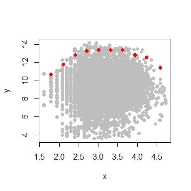

```
#>        x               y
#>  Min.   :1.792   Min.   :10.71
#>  1st Qu.:2.487   1st Qu.:11.98
#>  Median :3.162   Median :12.83
#>  Mean   :3.175   Mean   :12.55
#>  3rd Qu.:3.862   3rd Qu.:13.34
#>  Max.   :4.591   Max.   :13.37
```

```r
bins<-c(1.61,4.74,0.313)

blbin(x,y, bins,model = "explore", tau=0.99, pch=16, col="grey")
```

From the plot, it can be seen that a “trapezium” model will be more appropriate for this data set.

```r
startValues("trapezium")
```

The values for `start` can now be obtained and the function can now be run.

```r
start<-c(4.75, 3.23, 13.3, 24.87,-2.95 )

model2<-blbin(x,y, bins,start = start,model = "trapezium",
              tau=0.99,
              ylab=expression("t ha"^-1),
              xlab=expression("Phosphorus/ln(mg L"^-1*")"),
              pch=16, col="grey", bp_col="grey")
```

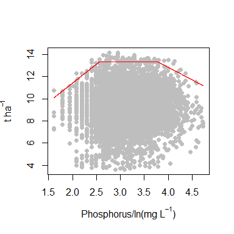

```r
model2
```

```
#> $Model
#> [1] "trapezium"
#>
#> $Equation
#> [1] y = min(β₁+ β₂x, β₀, β₃ + β₄x)
#>
#> $Parameters
#>     Estimate
#> β₁  4.595981
#> β₂  3.409921
#> β₀ 13.342115
#> β₃ 21.883246
#> β₄ -2.262389
#>
#> $RMS
#> [1] 0.01027899
```

The results show that the optimized parameters and plot. There is no uncertainty in the parameters because this is a heuristic method. These parameters can then be used to determine boundary line response for any given value of *`x`* using the `predictBL()` function.

### Quantile regression method

This method fits the boundary line using the principle of quantile regression (Cade and Noon, 2003). To fit the boundary line using the quantile regression method, the `blqr()` function can be used. To check the required arguments for the function, the help page can be launched.

```r
?blqr
```

The arguments *`x`* and *`y`* are the independent and dependent variable respectively and `start` is a vector of starting values . The `model` argument is used to specify the model of the boundary line e.g. “blm” for the linear model. The argument `tau` describes the quantile value described as boundary. We assume that the 99$^{\rm th}$ quantile (`tau=0.99`) value is the boundary. This is an arbitrary assumption, and for this reason we treat the method as heuristic.

The initial start start values can be determined as previously shown in the previous section. however, the `blqr()` function does not have the explore option and hence the `startValues()` function is used just on the plot of *`x`* and *`y`* directly according to the suggested model from the structure at the upper edge of the data. The trapezium model will be used for this data.

```r
plot(x,y)

startValues("trapezium")
```

The `start`values can now be used in the `blqr()` function.

```r
start<-c(4,3,13.5,31,-4.5)

model3<-blqr(x,y, start = start, model = "trapezium",
             xlab=expression("Phosphorus/ mg L"^-1),
             ylab=expression("Phosphorus/ln(mg L"^-1*")"),
             pch=16,tau=0.99, col="grey") # may take a few seconds to ran
```

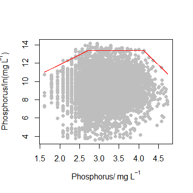

```r
model3
```

```
#> $Model
#> [1] "trapezium"
#>
#> $Equation
#> [1] y = min(β₁ + β₂x, β₀, β₃ + β₄x)
#>
#> $Parameters
#>     Estimate
#> β₁  7.559968
#> β₂  2.142848
#> β₀ 13.363650
#> β₃ 30.667717
#> β₄ -4.192797
#>
#> $RSS
#> [1] 252.7349
```

The results show that the optimized parameters and plot. The quantile regression method will produce measures of uncertainty for parameters, but BLA does not report these because they are conditional on the arbitrary choice of `tau`. These parameters can then be used to determine boundary line response for any given value of *`x`* using the `predictBL()` function.

### Censored bivariate normal model

To fit the boundary line using the Censored bivariate normal model method, see the `vignette("Censored_bivariate_normal_model")`.

### Using your own defined model

The illustrated methods for fitting the boundary line have some in-built models. These include the linear, linear plateau, mitscherlich, schmidt, logistic, logistic model proposed by Nelder (1961), the inverse logistic, double logistic, quadratic and the trapezium models. However, there are some cases where one wants to fit another model which is not part of the built in models. The following steps will illustrate how to fit a custom model. Though this will be illustrated using the `bolides()` function, it also applies for the `blbin()`, `blqr()` and `cbvn()` functions.

Assuming that the initial data exploratory step have been done, the first step is to check the structure of the boundary points using the argument `model="explore"` in the `bolides()` function.

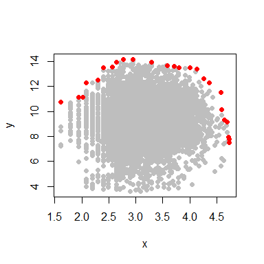

```
#>        x               y
#>  Min.   :1.609   Min.   : 7.513
#>  1st Qu.:2.583   1st Qu.:10.817
#>  Median :3.649   Median :12.566
#>  Mean   :3.464   Mean   :11.965
#>  3rd Qu.:4.520   3rd Qu.:13.575
#>  Max.   :4.736   Max.   :14.159
```

```r
bolides(x,y,model="explore", pch=16, col="grey")
```

Lets say you want to fit a model

$$y=\beta_0 - \beta_1(x-\beta_2)^2$$

The model is written in form of an `R` function and the parameters should always be written in alphabetical order as **a**, **b** and *c* for a three parameter function, **a**, **b**,**c** and *d* for four parameter function and so on.

```r
custom_function<-function(x,a,b,c){
  y<- a - b*(x-c)^2
}
```

The next step is to suggest the initial start `start` values. These should be sensible values else the function will not converge. These should be arranges in alphabetical order as `start=c(a,b,c)`. Replace a, b and c with numeric values of your choice.

The arguments of `bolides()` function can now be added. In this case, the argument model while be set to “other”. The arguments equation is now set to your custom function (`equation=custom_function`)

```r
start<-c(13.5,3,3.3)

model4<-bolides(x,y, start = start,model = "other",
                equation=custom_function,
                xlab=expression("Phosphorus/mg L"^-1),
                ylab=expression("Phosphorus/ln(mg L"^-1*")"),
                pch=16, ylim=c(3.8,14.5), col="grey",bp_col="grey")
```

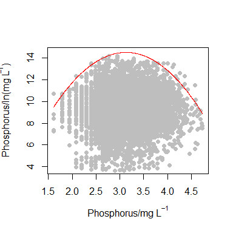

```r
model4
```

```
#> $Model
#> [1] "other"
#>
#> $Equation
#> function(x,a,b,c){
#>   y<- a - b*(x-c)^2
#> }
#> <bytecode: 0x000001d7137b0e98>
#>
#> $Parameters
#>    Estimate
#> a 14.498417
#> b  2.175998
#> c  3.128628
#>
#> $RMS
#> [1] 0.5166668
```

The parameters of the models are shown in the results. A prediction of the boundary response values for each value of *`x`* can the be done as previously shown using the `predictBL()` function.

## Closing remarks

The boundary line fitting methods illustrated here all use the optimization function to determine the parameters of the proposed models. To remove the risk of local optimum parameters, it is advised that the models are ran on several starting values and the results with the smallest error can be selected. Each method produces the error value in the output. It is residue mean square (RMS) for `blbin()` and `bolides()` while `blqr()` it is the residue sum squares (RSS). For the `cbvn()`, use the likelihood value.

# References

1. Cade, B. S., & Noon, B. R. (2003). A gentle introduction to quantile regression for ecologists. Frontiers in Ecology and the Environment, 1(8), 412-420. https://doi.org/10.1890/1540-9295(2003)001[0412:AGITQR]2.0.CO;2
2. Lark, R. M., Gillingham, V., Langton, D., & Marchant, B. P. (2020). Boundary line models for soil nutrient concentrations and wheat yield in national-scale datasets. European Journal of Soil Science, 71 , 334-351. https://doi.org/10.1111/ejss.12891
3. Milne, A. E., Wheeler, H. C., & Lark, R. M. (2006). On testing biological data for the presence of a boundary. Annals of Applied Biology, 149 , 213-222. https://doi.org/10.1111/j.1744-7348.2006.00085.x
4. Miti, C., Milne, A., Giller, K., Sadras, V., & Lark, R. (2024). Exploration of data for analysis using boundary line methodology. Computers and Electronics in Agriculture, 219. https://doi.org/10.1016/j.compag.2024.108794
5. Miti, C., Milne, A., Giller, K., & Lark, R. (2024). The concepts and quantification of yield gap using boundary lines. a review. Field Crops Research, 311. https://doi.org/10.1016/j.fcr.2024.109365.
6. Nelder, J.A. 1961. The fitting of a generalization of the logistic curve. Biometrics 17: 89–110. https://doi.org/10.2307/2527498
7. Rousseeuw, P. J., Ruts, I., & Tukey, J. W. (1999). The bagplot: A bivariate boxplot. The American Statistician, 53, 382–387. https://doi.org/10.1080/00031305.1999.10474494
8. Shatar, T. M., & McBratney, A. B. (2004). Boundary-line analysis of field-scale yield response to soil properties. Journal of Agricultural Science, 142 , 553-560.
9. Schnug, E., Heym, J. M., & Murphy, D. P. L. (1995). Boundary line determination technique (bolides). In P. C. Robert, R. H. Rust, & W. E. Larson (Eds.), site specific management for agricultural systems (p. 899-908). Wiley Online Library. https://doi.org/10.2134/1995.site-specificmanagement.c66
10. Webb, R. A. (1972). Use of the boundary line in analysis of biological data. Journal of Horticultural Science, 47, 309–319. https://doi.org/10.1080/00221589.1972.11514472